# LESSON 0: OVERALL INTRODUCTION

[figure not shown]

[figure not shown]

## 1. Anaconda introduction

### 1.1. Download and install anaconda

Install Anaconda on Windows: https://docs.anaconda.com/anaconda/install/windows/  
Install Anaconda on MacOS: https://docs.anaconda.com/anaconda/install/mac-os/

### 1.2. Interact with anaconda environment

Conda cheat sheet is available [here](https://docs.conda.io/projects/conda/en/4.6.0/_downloads/52a95608c49671267e40c689e0bc00ca/conda-cheatsheet.pdf).

#### Introduce to anaconda environment

- An anaconda environment is a directory that contains a specific collection of conda packages that you have installed.
- The environment is separated and independent to each other.
- Anaconda environments manage and run multiple python version on single computer.
- Anaconda manage and run lots of packages in different environments and reduce conflicts between them.

#### Check environment info

Run `conda info --envs` or `conda env list` to list environments which have installed.

#### Create anaconda environment

Run `conda create -n <ENV_NAME> python=<PYTHON_VERSION> -y` to create new environment with specific python version.  
Example: `conda create -n mci_env python=3.8 -y`.  
It can take time to create environment.

#### Activate an environment

Run `conda activate <ENV_NAME>` to activate the environment.  
Example: `conda activate mci_env`.  
After activating an environment, the running environment change from `base` to `mci_env` and we can check the python version by running `python --version` or `python -V`.

#### Install packages to an environment

The simple way is to run `conda install <PACKAGE_NAME> -y`  
We can specify the `channel` - where to locate and download the `packages`. Different `channel` can lead to different package version.  
To specify the `channel`, run `conda install -c <CHANNEL_NAME> <PACKAGE_NAME> -y`.  
Some popular anaconda channels:

- `main`: the default channel built by Anaconda, Inc
- `anaconda`: the mirror channel of `main` hosted in anaconda.org
- `conda-forge`: the community channel

Example:

- Installing `numpy`: `conda install -c anaconda numpy -y`
- Installing `pandas`: `conda install -c anaconda pandas -y`
- Installing `matplotlib`: `conda install -c conda-forge matplotlib -y`

We can specify the `version of package` that we want to install by running `conda install -c <CHANNEL_NAME> <PACKAGE_NAME>=<VERSION> -y`  
Example:

- Installing `numpy` version 1.21.2: `conda install -c anaconda numpy=1.21.2 -y`
- Installing `pandas` version 1.3.4: `conda install -c anaconda pandas=1.3.4 -y`
- Installing `matplotlib` version 3.5.0: `conda install -c conda-forge matplotlib=3.5.0 -y`

#### Remove package from an environment

Run `conda remove <PACKAGE_NAME>` to remove package from an environment.

#### List packages installed in an environment

Run `conda list` to list all packages installed in an environment.

#### Deactivate an environment

Run `conda deactivate` to deactivate the running environment and change back to `base`.

#### Remove an environment

Run `conda env remove --name <ENV_NAME>` to remove the environment.  
Example: `conda env remove --name mci_env`.  
After removing the environments, we can check `conda env list`.

## 2. Jupyter notebook introduction

### 2.1. Get started with jupyter notebook

To use jupyter notebook, please following these steps:

- Step 1: Activate conda environment
- Step 2: Install jupyter notebook by running `conda install -c anaconda jupyter`
- Step 3: Create a folder which contains document of MCI Python level 1
- Step 4: Run `jupyter notebook --notebook-dir=<PATH_TO_FOLDER_FROM_STEP_3>` to use jupyter notebook or run `jupyter lab --notebook-dir=<PATH_TO_FOLDER_FROM_STEP_3>` to use jupyter lab.
- Step 5: jupyter notebook or jupyter lab will be opened in browser with address `http://localhost:8888/`

We can run conda command (or any other commands) in jupyter notebook by using `!`. Example:

- List packages installed in an environment: `!conda list`
- Install `numpy`: `!conda install -c anaconda numpy -y`

### 2.2. Shortcuts in jupyter notebook

- `ESC` + `A`: Add a new cell above.
- `ESC` + `B`: Add a new cell below.
- `ESC` + `M`: Change a `code` cell into a `markdown` cell.
- `ESC` + `Y`: Change a `markdown` cell into a `code` cell.
- `ESC` + `D` + `D`: Remove a cell

## 3. Data science introduction

### 3.1. Workflow for data science

[figure not shown]

### 3.2. Skils for data science

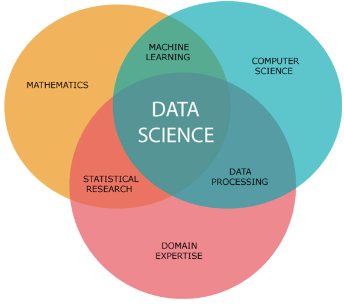